# PvFTa1 and flowering time in twenty Kano common bean accessions

- Show All Code
- Hide All Code
- View Source

A reproducible reanalysis of a screen-house trial

Author

Raphael Odera Onunkwor

Published

September 14, 2026

## Summary

*PvFTa1* is the common bean homologue of *Arabidopsis* FLOWERING LOCUS T and is treated in the breeding literature as a candidate locus for early flowering (González et al. 2016; Bhakta et al. 2017). Twenty *Phaseolus vulgaris* accessions collected from markets across ten Local Government Areas of Kano State, Nigeria, were grown in a screen house and scored for growth and flowering. Five accessions were amplified for a 300 bp *PvFTa1* fragment.

This report asks one question: **does carrying the *PvFTa1* amplicon track flowering time across this panel?**

The answer is no. The five genotyped accessions span the panel’s entire 18-day range in days to first flowering — they include both the earliest and the latest accession in the trial — and all five gave the product. A presence/absence assay at this locus has no discriminating power in this germplasm.

## The trial

The trial was my undergraduate research project, supervised by Dr K.E. Ogunsola at Bells University of Technology. Twenty accessions, two pots each, four seeds per pot thinned to two plants at week 2, in a completely randomised design: 80 plants. DNA extraction and amplification were carried out commercially. Growth traits were recorded weekly from week 2 to week 6; days to first flowering and days to 50% flowering were scored once per pot. The trial ran at the Department of Biological Sciences, Bells University of Technology, Ota, from November 2024 to July 2025.

The analysis below starts from the original recording sheet rather than from the summary table, so every number can be traced to a row of data.

```r
source("R/01_tidy_data.R")
```

```r
growth_long <- readr::read_csv(file.path(paths$derived, "growth_long.csv"),
                               show_col_types = FALSE)
week6 <- readr::read_csv(file.path(paths$derived, "week6_wide.csv"),
                         show_col_types = FALSE)
flowering <- readr::read_csv(file.path(paths$derived, "flowering.csv"),
                             show_col_types = FALSE)
```

### What the sheet actually contains

The export holds two stacked blocks of 40 rows. Before modelling anything, it is worth checking whether the two blocks are on a common scale.

```r
week6 |>
  select(reading, PH, NL, NB, LL, LB, SD) |>
  pivot_longer(-reading, names_to = "trait", values_to = "value") |>
  filter(!is.na(value)) |>
  group_by(trait, reading) |>
  summarise(mean = mean(value), .groups = "drop") |>
  pivot_wider(names_from = reading, values_from = mean,
              names_prefix = "block_") |>
  mutate(ratio = round(block_2 / block_1, 2)) |>
  arrange(desc(ratio))
```

| trait | block_1 | block_2 | ratio |
| --- | --- | --- | --- |
| SD | 0.5445161 | 3.732813 | 6.86 |
| PH | 81.7166667 | 245.918750 | 3.01 |
| NL | 60.4333333 | 105.500000 | 1.75 |
| LL | 8.2103448 | 9.884375 | 1.20 |
| LB | 5.6172414 | 6.556250 | 1.17 |
| NB | 2.0714286 | 2.100000 | 1.01 |

They are not. Block 2 runs about three times higher than block 1 for plant height and about seven times higher for stem diameter. A factor of seven on a stem diameter is a change of measurement scale, not of plants — two seedlings thinned from the same pot cannot differ that way. Every model below therefore carries `reading` as a fixed effect, and stem-diameter results are not comparable across blocks.

This is the kind of thing that only surfaces by going back to the raw sheet.

## Flowering phenology

```r
pheno <- flowering |>
  filter(!is.na(dtff)) |>
  group_by(accession_code, accession, pvfta1) |>
  summarise(dtff = first(dtff), dt50 = first(dt50),
            category = first(category), .groups = "drop") |>
  arrange(dtff)

pheno |> select(accession, dtff, dt50, category, pvfta1)
```

| accession | dtff | dt50 | category | pvfta1 |
| --- | --- | --- | --- | --- |
| Kumbotso3 | 28 | 38 | Early | Amplified |
| Yankaba19 | 30 | 38 | Early | Amplified |
| Kura1 | 32 | 38 | Early | Not genotyped |
| Dawaki18 | 32 | 38 | Early | Not genotyped |
| Bichi6 | 33 | 38 | Early | Not genotyped |
| Sumailia7 | 34 | 39 | Early | Not genotyped |
| Dawakin11 | 35 | 38 | Early | Not genotyped |
| Kwanar14 | 35 | 38 | Early | Not genotyped |
| Danhassan2 | 36 | 42 | Intermediate | Amplified |
| Gani8 | 36 | 38 | Early | Amplified |
| Rano9 | 36 | 38 | Early | Not genotyped |
| Sabuwar20 | 36 | 38 | Early | Not genotyped |
| Danzabura5 | 37 | 45 | Intermediate | Not genotyped |
| Darki16 | 42 | 47 | Late | Not genotyped |
| Ruwan10 | 45 | 47 | Late | Not genotyped |
| Dawanao12 | 46 | 51 | Late | Amplified |

Sixteen of the twenty accessions carry a flowering record in the sheet. Days to first flowering runs from **28** days (Kumbotso3) to **46** days (Dawanao12), a spread of **18** days.

### A note on zero variance

Both pots of every accession recorded exactly the same flowering dates.

```r
flowering |>
  filter(!is.na(dtff)) |>
  group_by(accession) |>
  summarise(dtff_sd = sd(dtff), dt50_sd = sd(dt50), .groups = "drop") |>
  summarise(`accessions with any within-accession variation` =
              sum(dtff_sd > 0 | dt50_sd > 0, na.rm = TRUE),
            `accessions checked` = n())
```

| accessions with any within-accession variation | accessions checked |
| --- | --- |
| 0 | 16 |

Within-accession variance is exactly zero. An F ratio for accession would have a zero denominator, so ANOVA and any mean-separation test built on it are undefined for these traits. Days to flowering is treated here as one fixed observed value per accession rather than as a sample with error. This is a limitation of how the trait was scored, not a property of the biology.

## Does PvFTa1 track flowering time?

```r
genotyped <- pheno |> filter(pvfta1 == "Amplified")

tibble(
  metric = c("Accessions genotyped", "Gave the 300 bp product",
             "Earliest genotyped (days)", "Latest genotyped (days)",
             "Panel range (days)", "Genotyped range (days)",
             "Share of panel range covered"),
  value = c(nrow(genotyped), nrow(genotyped),
            min(genotyped$dtff), max(genotyped$dtff),
            max(pheno$dtff) - min(pheno$dtff),
            max(genotyped$dtff) - min(genotyped$dtff),
            sprintf("%.0f%%", 100 * (max(genotyped$dtff) - min(genotyped$dtff)) /
                      (max(pheno$dtff) - min(pheno$dtff))))
)
```

| metric | value |
| --- | --- |
| Accessions genotyped | 5 |
| Gave the 300 bp product | 5 |
| Earliest genotyped (days) | 28 |
| Latest genotyped (days) | 46 |
| Panel range (days) | 18 |
| Genotyped range (days) | 18 |
| Share of panel range covered | 100% |

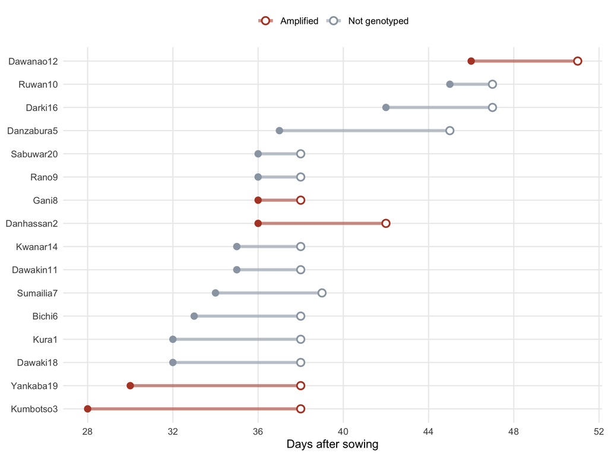

Figure 1: Flowering window per accession. Filled point: days to first flowering. Open point: days to 50% flowering. Accessions amplified for PvFTa1 in red.

```r
pal <- c("Amplified" = "#B4462F", "Not genotyped" = "#9AA5B1")

pheno |>
  mutate(accession = forcats::fct_reorder(accession, dtff)) |>
  ggplot(aes(x = dtff, y = accession, colour = pvfta1)) +
  geom_segment(aes(xend = dt50, yend = accession), linewidth = 1.4, alpha = .55) +
  geom_point(size = 2.6) +
  geom_point(aes(x = dt50), size = 2.6, shape = 21, fill = "white", stroke = 1.1) +
  scale_colour_manual(values = pal, name = NULL) +
  scale_x_continuous(breaks = seq(28, 52, 4)) +
  labs(x = "Days after sowing", y = NULL) +
  theme_minimal(base_size = 11) +
  theme(legend.position = "top", panel.grid.minor = element_blank())
```

The red points are not clustered at the early end. They run the length of the axis: the earliest accession in the trial and the latest are both *PvFTa1* positive, as is an intermediate one. Whatever separates a 28-day accession from a 46-day accession here, it is not presence of this amplicon.

Two readings are consistent with that. Either the locus is effectively fixed across these landraces, or the variation that matters is sequence-level rather than presence/absence. Both point to the same next experiment: sequence the amplicon and look for polymorphism, rather than screening more accessions for the band.

## Are the accessions distinguishable at all?

If the panel showed strong, clean genotype differences in every other trait, the null *PvFTa1* result would look more surprising. It does not.

### One-way ANOVA and Duncan’s test

```r
traits <- c(PH = "Plant height (cm)", NL = "Number of leaves",
            NB = "Number of branches", LL = "Leaf length (cm)",
            LB = "Leaf breadth (cm)", SD = "Stem diameter")

anova_summary <- purrr::map_dfr(names(traits), function(tr) {
  d <- week6 |>
    select(accession, reading, value = all_of(tr)) |>
    filter(!is.na(value)) |>
    mutate(across(c(accession, reading), factor))
  fit <- aov(value ~ accession + reading, data = d)
  broom::tidy(fit) |>
    filter(term == "accession") |>
    transmute(trait = traits[[tr]], df, F = round(statistic, 2),
              p = signif(p.value, 3))
})

anova_summary
```

| trait | df | F | p |
| --- | --- | --- | --- |
| Plant height (cm) | 19 | 1.72 | 0.0726 |
| Number of leaves | 19 | 1.70 | 0.0759 |
| Number of branches | 19 | 1.73 | 0.0645 |
| Leaf length (cm) | 19 | 1.08 | 0.4010 |
| Leaf breadth (cm) | 19 | 1.36 | 0.2040 |
| Stem diameter | 19 | 31.94 | 0.0000 |

Only stem diameter clears `p = 0.05`, and that result is an artefact: removing the between-block scale difference collapses the residual variance, so the test is really detecting which accessions were measured in which block. Discounting it, **no growth trait shows a significant accession effect at week 6.**

### Where the variance actually sits

A mixed model puts a number on that. Measurements are nested — accession, then pot within accession, then the individual plant — and `reading` cuts across all three.

```r
vc <- purrr::map_dfr(names(traits), function(tr) {
  d <- week6 |>
    select(accession, pot, reading, value = all_of(tr)) |>
    filter(!is.na(value)) |>
    mutate(across(c(accession, pot, reading), factor))

  fit <- lme4::lmer(value ~ reading + (1 | accession) + (1 | accession:pot),
                    data = d, REML = TRUE,
                    control = lme4::lmerControl(check.conv.singular = "ignore"))

  v <- as.data.frame(lme4::VarCorr(fit))
  pick <- function(g) { x <- v$vcov[v$grp == g]; if (length(x)) x else 0 }
  a <- pick("accession"); p <- pick("accession:pot"); r <- pick("Residual")

  tibble(Trait = traits[[tr]], n = nrow(d),
         Accession = sprintf("%.1f%%", 100 * a / (a + p + r)),
         Pot       = sprintf("%.1f%%", 100 * p / (a + p + r)),
         Residual  = sprintf("%.1f%%", 100 * r / (a + p + r)))
})

vc
```

| Trait | n | Accession | Pot | Residual |
| --- | --- | --- | --- | --- |
| Plant height (cm) | 62 | 8.0% | 0.0% | 92.0% |
| Number of leaves | 62 | 6.8% | 13.6% | 79.6% |
| Number of branches | 68 | 9.6% | 29.6% | 60.7% |
| Leaf length (cm) | 61 | 0.8% | 0.0% | 99.2% |
| Leaf breadth (cm) | 61 | 7.5% | 0.0% | 92.5% |
| Stem diameter | 63 | 0.0% | 0.0% | 100.0% |

Accession identity accounts for under 10% of total variance in every vegetative trait. The overwhelming share sits in the residual — variation between individual plants and between recording sessions.

This does **not** show the accessions are identical. It shows this trial cannot resolve vegetative differences between them: two pots per accession, heavy missing data, and two recording sessions that differ systematically leave very little power. The honest conclusion is that flowering time is the only phenotype in this dataset that is sharply structured, and it happens to be the one the marker was supposed to explain.

## A mechanistic check: how big a difference would it take?

The result above is negative, and negative results are worth pressing on. If presence of *PvFTa1* does not explain an 18-day spread, how large a difference in the gene’s activity *would*?

Reduce the floral transition to its minimum. Photoperiod drives FT production, FT accumulates, and the plant commits to flowering when the accumulated signal crosses a threshold $\theta$:

$$\frac{dF}{dt} = \alpha - \delta F, \qquad F(0) = 0, \qquad \text{flowering when } F = \theta$$

The trial sat at 6.7°N, where daylength varies by under an hour across the year, so holding $\alpha$ constant within an accession is defensible here in a way it would not be at temperate latitude.

```r
ft_ode <- function(t, state, parms) {
  with(as.list(c(state, parms)), list(c(dF = alpha - delta * F)))
}
solve_numeric <- function(alpha, delta, times) {
  as.numeric(deSolve::ode(y = c(F = 0), times = times, func = ft_ode,
                          parms = list(alpha = alpha, delta = delta))[, "F"])
}
# Integrating factor gives the closed form.
solve_analytic <- function(alpha, delta, times) {
  (alpha / delta) * (1 - exp(-delta * times))
}

times <- seq(0, 60, by = 0.5)
max(abs(solve_numeric(0.05, 0.03, times) - solve_analytic(0.05, 0.03, times)))
```

```
[1] 1.008963e-06
```

The solver and the closed form agree to about $10^{-6}$, which is the check that licenses using either one.

### What the data can identify

Setting $F(t^\*) = \theta$ and solving,

$$t^\* = -\frac{1}{\delta}\log\!\left(1 - \frac{\theta\delta}{\alpha}\right)$$

$\alpha$ and $\theta$ enter only through their ratio, so no collection of flowering dates can separate them. Fixing $\theta = 1$ costs nothing and makes $\alpha$ a rate in units of the threshold. $\delta$ is not identified either by one date per accession, so it is scanned rather than estimated.

```r
implied_alpha <- function(t_obs, delta, theta = 1) {
  theta * delta / (1 - exp(-delta * t_obs))
}

delta_grid <- 10^seq(-3, 0, length.out = 60)
rate_scan <- tidyr::expand_grid(delta = delta_grid,
                                pheno |> select(accession, dtff, pvfta1)) |>
  mutate(alpha = implied_alpha(dtff, delta))

fold_range <- rate_scan |>
  group_by(delta) |>
  summarise(fold = max(alpha) / min(alpha), .groups = "drop")

tibble(`largest rate ratio the spread requires` = round(max(fold_range$fold), 3))
```

| largest rate ratio the spread requires |
| --- |
| 1.628 |

These per-accession rates are a **reparameterisation of the observed dates, not an independent estimate**: one date fixes one rate exactly.

### The finding

Across every turnover rate considered, the panel’s full 28-to-46 day spread requires at most a **1.63-fold** difference in FT production rate. A change that small sits comfortably within ordinary regulatory variation. It does not require a gene to be present in one accession and absent in another.

So the model agrees with the marker data rather than contradicting it: a conserved locus with quantitative differences in output is sufficient to generate everything observed.

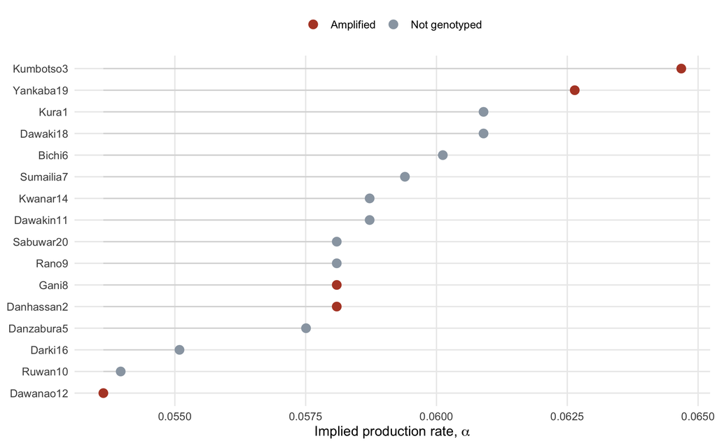

Figure 2: Implied FT production rate per accession at delta = 0.05. The PvFTa1-amplified accessions are the panel maximum and minimum.

```r
rate_ref <- rate_scan |> filter(abs(delta - 0.05) == min(abs(delta - 0.05)))

rate_ref |>
  mutate(accession = forcats::fct_reorder(accession, alpha)) |>
  ggplot(aes(alpha, accession, colour = pvfta1)) +
  geom_segment(aes(x = min(alpha), xend = alpha, yend = accession),
               linewidth = .5, colour = "grey85") +
  geom_point(size = 3) +
  scale_colour_manual(values = pal, name = NULL) +
  labs(x = expression("Implied production rate, "*alpha), y = NULL) +
  theme_minimal(base_size = 11) +
  theme(legend.position = "top", panel.grid.minor = element_blank())
```

Asked on the mechanistic scale, the comparison gives the same answer as the raw phenotype:

```r
amp <- rate_ref |> filter(pvfta1 == "Amplified")
oth <- rate_ref |> filter(pvfta1 != "Amplified")
tibble(
  `amplified range` = sprintf("%.4f - %.4f", min(amp$alpha), max(amp$alpha)),
  `panel range`     = sprintf("%.4f - %.4f", min(rate_ref$alpha), max(rate_ref$alpha)),
  `Wilcoxon p`      = round(suppressWarnings(wilcox.test(amp$alpha, oth$alpha))$p.value, 3)
)
```

| amplified range | panel range | Wilcoxon p |
| --- | --- | --- |
| 0.0536 - 0.0647 | 0.0536 - 0.0647 | 0.807 |

### A model that was deliberately not fitted

Days to 50% flowering would in principle supply a second threshold crossing and make $\delta$ estimable. It cannot here:

```r
pheno |> count(dt50, name = "accessions") |> arrange(desc(accessions))
```

| dt50 | accessions |
| --- | --- |
| 38 | 10 |
| 47 | 2 |
| 39 | 1 |
| 42 | 1 |
| 45 | 1 |
| 51 | 1 |

With 62% of the panel sharing a single recorded value, the interval between first and 50% flowering is close to a linear function of the first date by construction. A fitted second threshold would be reporting that artefact as biology, so the model stops here.

### What it says to do next

Flowering date is a sensitive readout of production rate: around the panel median, a 10% difference in $\alpha$ moves flowering by roughly seven days. That sensitivity is why a presence/absence assay is the wrong instrument. Telling these accessions apart requires measurement where the variation actually lives, at the level of expression or sequence.

## Departures from the original write-up

Rebuilding from the sheet surfaced several discrepancies with the original analysis, recorded here rather than quietly repaired.

[output not shown]

## Conclusion

Flowering time in this panel spans 18 days and is the one trait the trial resolves cleanly. Every accession tested for *PvFTa1* carried the 300 bp fragment, including both phenotypic extremes, so the locus is more conserved across this germplasm than the phenotypic spread would predict. Presence of the amplicon is not a usable marker for flowering time here.

The productive next step is sequence-level: amplify and sequence *PvFTa1* across the full panel and test for polymorphism against flowering date, rather than scoring further accessions for presence of the band.

## Reproducing this report

```
Rscript R/00_packages.R              # once
quarto render report/pvfta1-phenology.qmd
```

## Acknowledgements

The underlying trial was my B.Tech. research project in the Department of Biological Sciences, Bells University of Technology, Ota, supervised by Dr K.E. Ogunsola. This reanalysis was carried out independently in 2026, after the thesis had been submitted and examined; the departures from the original analysis documented above, and any errors here, are mine alone.

## References

Bhakta, Mehul S., Salvador A. Gezan, José A. Clavijo Michelangeli, et al. 2017. “A Predictive Model for Time-to-Flowering in the Common Bean Based on QTL and Environmental Variables.” *G3: Genes, Genomes, Genetics* 7 (12): 3901–12.

González, Ana M., Fernando J. Yuste-Lisbona, Antonio Fernández-Lozano, et al. 2016. “The Homologues of Arabidopsis FLOWERING LOCUS T and GIGANTEA Genes Are Involved in the Control of Photoperiod Response of Flowering in Common Bean.” *Frontiers in Plant Science* 7: 1234.